# Income and Wealth Inequality Data Visualization

Jasmin Dial

12/11/2017

#### Plot 1

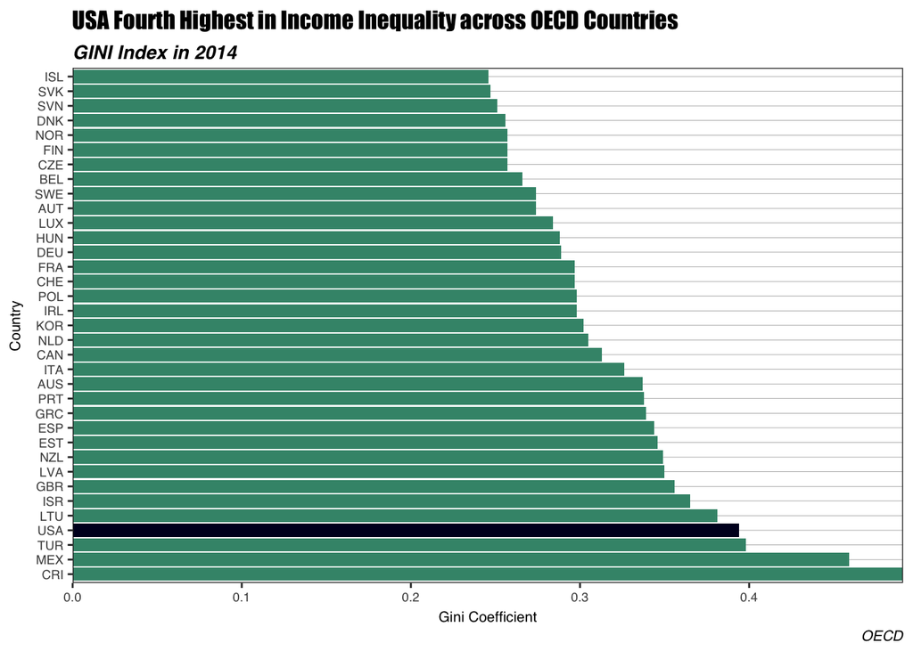

Based on the value of Gini Coefficients, a metric for inequality of income distribution, the United States is one of the most unequal countries in the OECD. In 2014, it ranked below only three other countries.

#### Plot 2

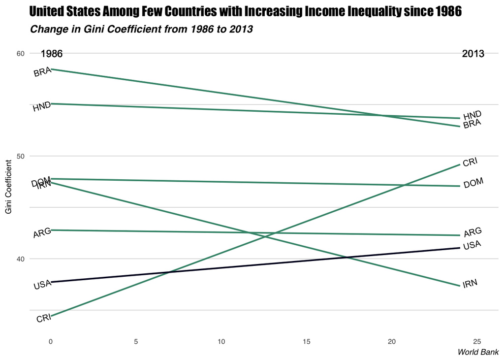

When we compare the United States to even more countries, it becomes apparent that many other countries have high income inequality, but not all of them have had increasing income inequality over time. In this graph of countries with Gini Coefficient data available in 1986 and 2013, the only one other country with increased Gini since 1986 is Costa Rica, which currently has the highest Gini among OECD countries.

#### Plot 3

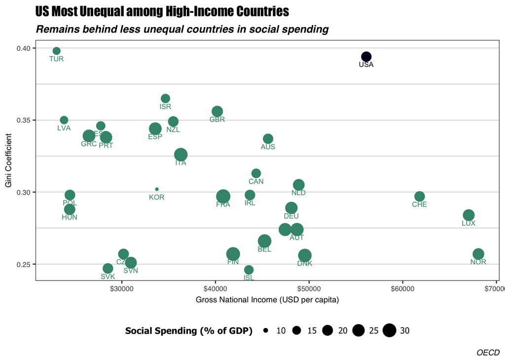

According to Our World in Data, countries with higher income tend to have lower inequality. However, the Unites States is once again an outlier, having the highest income inequality even among higher income countries. While other countries may try to address their high inequality through social spending like cash benefits and tax breaks, the US also lags behind OECD countries in terms of public social spending.

#### Plot 4

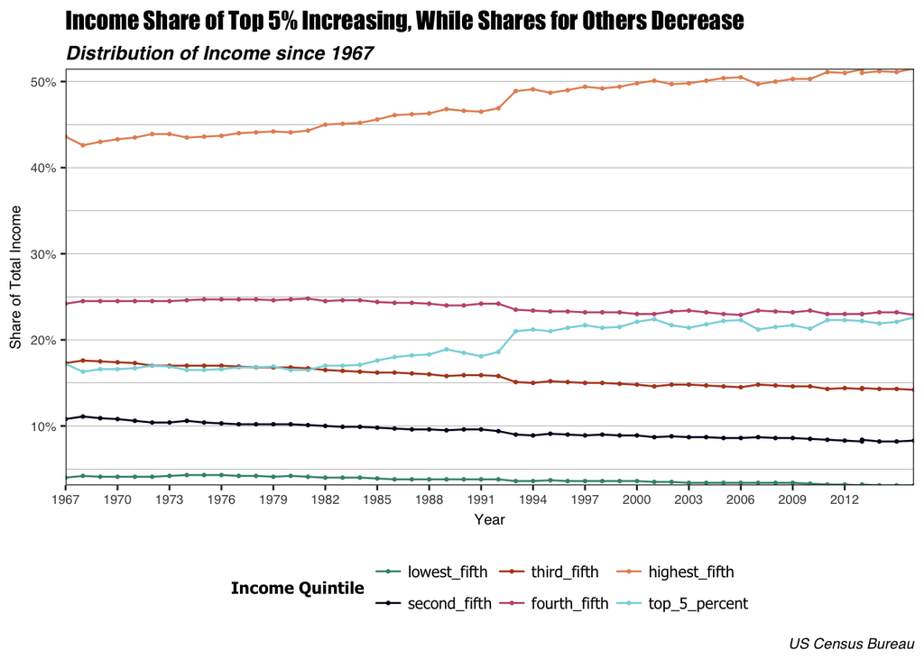

[output not shown]

#### Plot 5

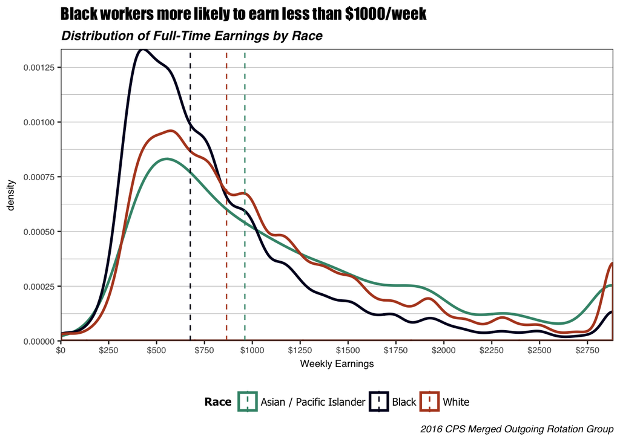

Further patterns of income inequality emerge when earnings are separated by race. A larger percentage of Black full-time workers earned less than $1000 per week in 2016 compared to White and Asian workers. The dashed lines show median income for each group - black workers have the lowest median, and the earnings of Asian workers are less skewed than White earners.

#### Plot 6

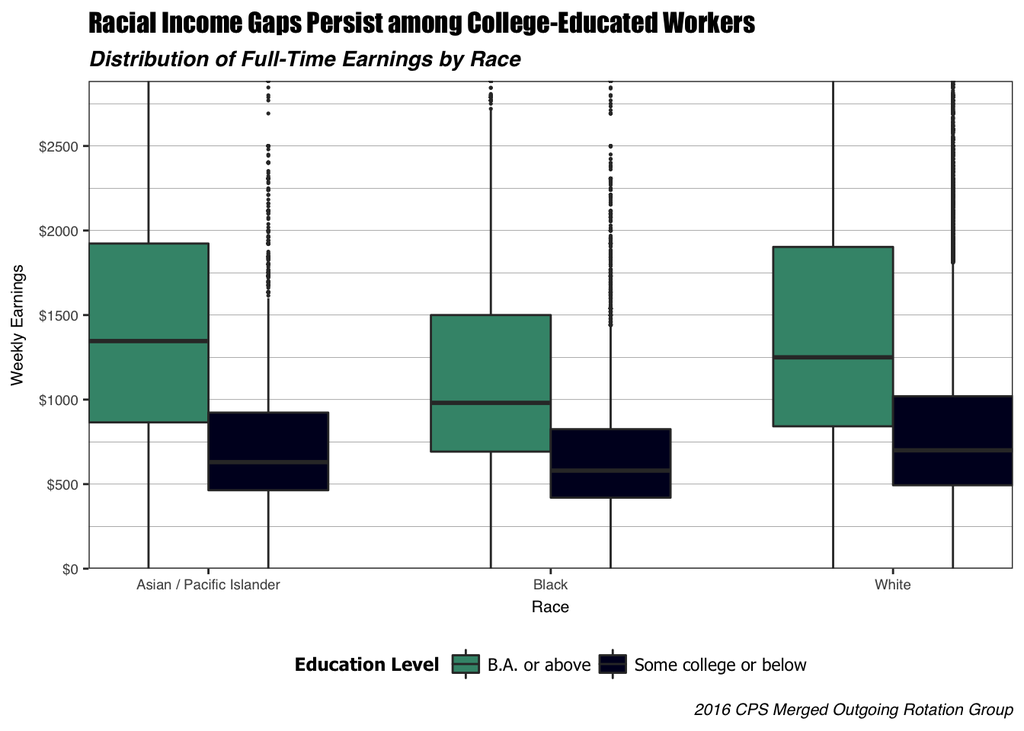

Higher education is often viewed as the great equalizer of social inequities. Generally, those that earn at least Bachelor’s Degree have higher incomes than those who do not complete college, and plot 6 shows that this is true among three racial categories. Despite the demonstrated facial benefits of earning a B.A., this accomplishment does not entirely close the gap between Black, Asian, and White workers. The median wage for college-educated Black workers is higher than non-college-educated White workers, but the difference in median incomes between Black workers and White workers is even greater among college-educated workers than non-college-educated workers.

#### Plot 7

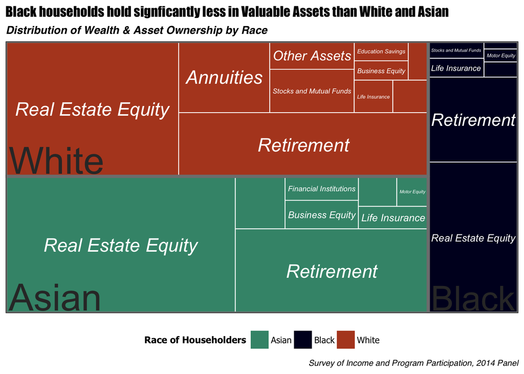

#### Plot 8

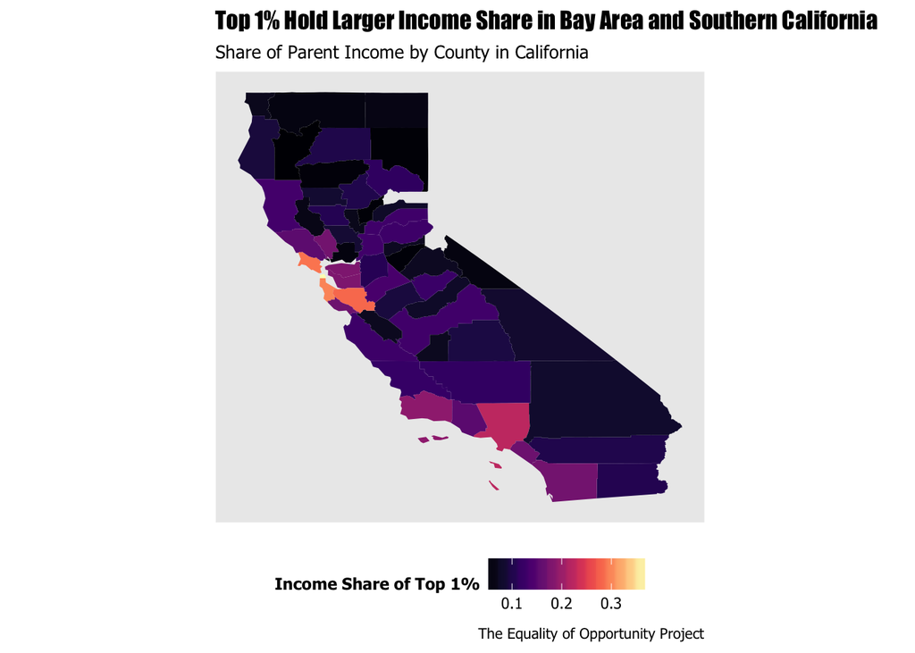